# 일반화선형모형 중간고사

20180968 박서현

2020 10 21

```r
#install.packages('DescTools')
#install.packages("car")
library(binom)
```

```r
library(ggplot2)
library(PropCIs)
library(data.table)
library(readxl)
library(epitools)
library(DescTools)
library(dplyr)
library(MASS)
library(car)
library(lmtest)
```

# 1.

```r
placebo <- matrix(c(16, 48, 40, 20), byrow=T, ncol=2)
dimnames(placebo) <- list(medicine=c("위약", "시험약"), result=c("개선됨(favor)", "개선 안됨(unfavor)"))
placebo
```

```
##         result
## medicine 개선됨(favor) 개선 안됨(unfavor)
##   위약              16                 48
##   시험약            40                 20
```

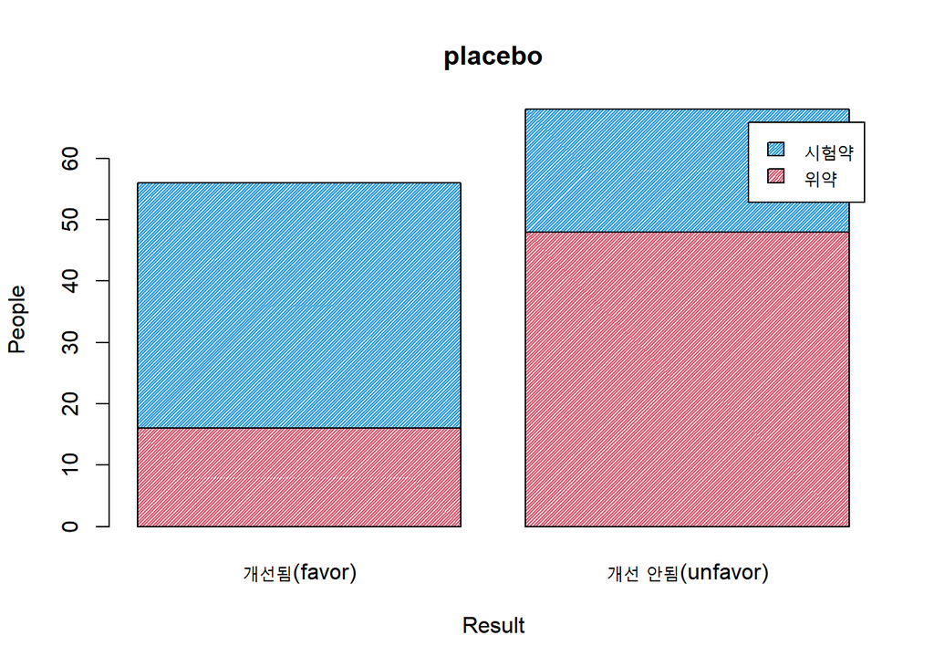

```r
barplot(placebo, density = 60, legend.text=T, col=c(2, 4), main="placebo", xlab="Result", ylab="People")
```

## 1)

```r
round(addmargins(prop.table(placebo, 1)), 2)
```

```
##         result
## medicine 개선됨(favor) 개선 안됨(unfavor) Sum
##   위약            0.25               0.75   1
##   시험약          0.67               0.33   1
##   Sum             0.92               1.08   2
```

- 위약의 개선 비율: 0.25
- 시험약의 개선 비율: 0.67

```r
pro_test=prop.test(placebo, correct = FALSE)
pro_test
```

```
##
##  2-sample test for equality of proportions without continuity
##  correction
##
## data:  placebo
## X-squared = 21.709, df = 1, p-value = 3.174e-06
## alternative hypothesis: two.sided
## 95 percent confidence interval:
##  -0.5762972 -0.2570362
## sample estimates:
##    prop 1    prop 2
## 0.2500000 0.6666667
```

- 95% 비율차이에 대한 왈드 신뢰구간: (-0.5763, -0.2570)
- 유의수준 0.05에서 위약과 시험약간의 개선에 유의한 차이가 있음을 알 수 있다.

## 2)

```r
prop.out <- prop.table(placebo, margin=1)
prop.out
```

```
##         result
## medicine 개선됨(favor) 개선 안됨(unfavor)
##   위약       0.2500000          0.7500000
##   시험약     0.6666667          0.3333333
```

```r
prop.out[1, 1] / prop.out[2, 1]
```

```
## [1] 0.375
```

- 위약과 시험약 개선 비율에 대한 상대위험도: 0.375

```r
rr.out <- riskratio(placebo, rev="both")
rr.out$measure
```

```
##         risk ratio with 95% C.I.
## medicine estimate     lower     upper
##   시험약    1.000        NA        NA
##   위약      0.375 0.2366078 0.5943379
```

## 3)

```r
OddsRatio(placebo, conf.level=0.95)
```

```
## odds ratio     lwr.ci     upr.ci
## 0.16666667 0.07640928 0.36353932
```

- 오즈비: 0.16667
- 위약으로 개선될 가능성ㅇ 시험약으로 개선될 가능성보다 낮다.

## 4)

```r
oddsratio(placebo, method="wald", correction = FALSE, conf.level = 0.95)
```

```
## $data
##         result
## medicine 개선됨(favor) 개선 안됨(unfavor) Total
##   위약              16                 48    64
##   시험약            40                 20    60
##   Total             56                 68   124
##
## $measure
##         odds ratio with 95% C.I.
## medicine  estimate      lower     upper
##   위약   1.0000000         NA        NA
##   시험약 0.1666667 0.07640928 0.3635393
##
## $p.value
##         two-sided
## medicine   midp.exact fisher.exact   chi.square
##   위약             NA           NA           NA
##   시험약 3.278046e-06 4.754071e-06 3.173515e-06
##
## $correction
## [1] FALSE
##
## attr(,"method")
## [1] "Unconditional MLE & normal approximation (Wald) CI"
```

- 오즈비에 대한 신뢰구간은 (0.0764, 0.3635)이다.
- 신뢰구간에 1을 포함하고 있지 않아 개선될 오즈는 두 집단간에 서로 다르다.

## 5

```r
pla_test = chisq.test(placebo, correct = FALSE)
pla_test
```

```
##
##  Pearson's Chi-squared test
##
## data:  placebo
## X-squared = 21.709, df = 1, p-value = 3.174e-06
```

```r
pla_test$expected
```

```
##         result
## medicine 개선됨(favor) 개선 안됨(unfavor)
##   위약        28.90323           35.09677
##   시험약      27.09677           32.90323
```

- 각 셀의 기대도수 추정치이다.

## 6)

- 귀무가설: 호흡기질환 환자들에 대한 처리와 반응이 통계적으로 서로 독립이다.

```r
chisq.test(placebo)
```

```
##
##  Pearson's Chi-squared test with Yates' continuity correction
##
## data:  placebo
## X-squared = 20.059, df = 1, p-value = 7.509e-06
```

```r
G2 <- function(data){
  X2 <- chisq.test(data)
  mle <- X2$expected
  df <- X2$parameter
  term.G2 <- data*log(data/mle)
  term.G2[data==0] <- 0
  G2 <- 2*sum(term.G2)
  p <- 1-pchisq(G2, df)
  return (list(G2=G2, df=df, p.value=p))
}
G2(placebo)
```

```
## $G2
## [1] 22.37679
##
## $df
## df
##  1
##
## $p.value
## [1] 2.240653e-06
```

- 호흡기질환 환자들에 대한 처리와 반응이 통계적으로 서로 독립이 아니다!

# 2.

```r
birthdata <-  as.data.frame(read_excel("C:/Users/nabib/Documents/GitHub/Statics/1021/birthdata.xlsx"))
birthdata
```

```
##     age children
## 1    31        1
## 2    34        0
## 3    34        0
## 4    31        1
## 5    43        0
## 6    32        0
## 7    36        0
## 8    31        0
## 9    38        0
## 10   36        1
## 11   35        0
## 12   22        0
## 13   33        0
## 14   25        0
```

[output cut: 127 more lines]

## 1)

- 포아송회귀모형
  - 이산반응의 결과가 도수(count)인 음이 아닌 정수의 경우의 일반화선형모형
  - 분산이 평균보다 커서 과대산포가 발생 시에는 포아송 회귀모형을 사용할 수 없다.
- 음이항회귀모형
  - 음수가 아닌 정수값을 취하는 분포
  - 모든 예측값에 대하여 산포 모수 D가 동일한 값을 갖는다고 가정함.

```r
mean(birthdata$children)
```

```
## [1] 0.6028369
```

```r
var(birthdata$children)
```

```
## [1] 1.012563
```

- 평균이 0.6, 분산이 1.01으로 과대산포가 발생한다. 즉 포아송회귀모형보다 음이항회귀모형이 적합하다.

```r
birth.poi <- glm(children ~ age, family = poisson(link=log), data=birthdata)
summary(birth.poi)
```

```
##
## Call:
## glm(formula = children ~ age, family = poisson(link = log), data = birthdata)
##
## Deviance Residuals:
##     Min       1Q   Median       3Q      Max
## -2.0753  -0.9960  -0.7510   0.5358   2.8532
##
## Coefficients:
##             Estimate Std. Error z value Pr(>|z|)
## (Intercept) -4.08955    0.71361  -5.731    1e-08 ***
## age          0.11295    0.02121   5.326    1e-07 ***
## ---
## Signif. codes:  0 '***' 0.001 '**' 0.01 '*' 0.05 '.' 0.1 ' ' 1
##
## (Dispersion parameter for poisson family taken to be 1)
##
##     Null deviance: 194.42  on 140  degrees of freedom
## Residual deviance: 165.01  on 139  degrees of freedom
## AIC: 289.98
##
## Number of Fisher Scoring iterations: 5
```

- 포아송회귀모형의 적합식

$$\widehat{\mu} = -4.090+0.113x$$

```r
birth.nb <- glm.nb(children ~ age, data=birthdata)
summary(birth.nb)
```

```
##
## Call:
## glm.nb(formula = children ~ age, data = birthdata, init.theta = 1.815795639,
##     link = log)
##
## Deviance Residuals:
##     Min       1Q   Median       3Q      Max
## -1.6911  -0.9364  -0.7226   0.4562   2.3823
##
## Coefficients:
##             Estimate Std. Error z value Pr(>|z|)
## (Intercept) -4.11377    0.84095  -4.892 9.99e-07 ***
## age          0.11374    0.02559   4.444 8.84e-06 ***
## ---
## Signif. codes:  0 '***' 0.001 '**' 0.01 '*' 0.05 '.' 0.1 ' ' 1
##
## (Dispersion parameter for Negative Binomial(1.8158) family taken to be 1)
##
##     Null deviance: 146.59  on 140  degrees of freedom
## Residual deviance: 124.80  on 139  degrees of freedom
## AIC: 285.58
##
## Number of Fisher Scoring iterations: 1
##
##
##               Theta:  1.82
##           Std. Err.:  1.02
##
##  2 x log-likelihood:  -279.579
```

- 음이항회귀분석 적합식

$$log \widehat{\mu} = -4.114+0.114x$$

- AIC 값이 포아송회귀모형은 289.98, 음이항회귀모형은 285.58로 음이항회귀모형의 AIC 값이 더 작다. 따라서 포아송회귀모형보다 음이항회귀모형이 더 낫다.

## 2)

```r
birth.poi$fitted.values
```

```
##         1         2         3         4         5         6         7         8
## 0.5553027 0.7792637 0.7792637 0.5553027 2.1535173 0.6217007 0.9767593 0.5553027
##         9        10        11        12        13        14        15        16
## 1.2243078 0.9767593 0.8724408 0.2009398 0.6960379 0.2819814 0.3156982 0.3957083
##        17        18        19        20        21        22        23        24
## 0.6217007 0.6217007 0.4430234 0.2819814 0.3534464 0.3156982 0.6217007 0.4430234
##        25        26        27        28        29        30        31        32
## 0.2819814 0.5553027 1.9235205 0.6217007 1.3706993 1.3706993 0.3957083 1.7180875
##        33        34        35        36        37        38        39        40
## 0.9767593 0.3957083 0.2249663 0.1431895 0.5553027 0.4430234 0.4430234 0.7792637
##        41        42        43        44        45        46        47        48
## 0.3957083 1.0935511 0.2518657 0.3957083 0.7792637 0.3957083 0.5553027 0.6960379
##        49        50        51        52        53        54        55        56
## 0.4430234 0.5553027 0.9767593 0.3534464 0.7792637 0.3534464 0.3957083 0.6217007
##        57        58        59        60        61        62        63        64
## 0.5553027 0.4959961 1.0935511 0.1603108 0.5553027 0.3957083 1.5345948 0.9767593
##        65        66        67        68        69        70        71        72
## 0.4430234 0.5553027 0.9767593 1.0935511 0.5553027 0.9767593 0.1794793 0.3957083
##        73        74        75        76        77        78        79        80
## 0.8724408 0.2249663 0.6960379 0.4959961 0.3534464 0.8724408 0.3156982 0.1603108
##        81        82        83        84        85        86        87        88
## 0.6217007 0.4430234 0.3156982 1.0935511 0.3156982 0.8724408 0.1603108 0.5553027
##        89        90        91        92        93        94        95        96
## 0.4959961 1.0935511 0.4430234 0.4430234 0.5553027 0.5553027 0.3534464 0.1278968
##        97        98        99       100       101       102       103       104
## 0.2819814 0.1603108 0.7792637 1.5345948 0.3534464 0.6960379 0.6960379 0.8724408
##       105       106       107       108       109       110       111       112
## 0.4430234 0.4430234 1.0935511 0.2249663 0.9767593 0.3156982 0.8724408 0.3957083
##       113       114       115       116       117       118       119       120
## 0.2819814 0.4959961 0.3156982 0.1794793 0.3957083 0.2819814 0.4959961 0.8724408
##       121       122       123       124       125       126       127       128
## 0.9767593 0.4959961 0.6960379 0.4430234 0.3957083 0.2518657 0.2518657 0.4430234
##       129       130       131       132       133       134       135       136
## 0.4959961 0.4959961 0.1794793 1.0935511 0.7792637 0.5553027 0.1794793 0.2819814
##       137       138       139       140       141
## 0.1142373 0.6217007 0.1603108 0.4430234 1.9235205
```

- 포아송회귀분석에서의 예측값: 0.779

```r
birth.nb$fitted.values
```

```
##         1         2         3         4         5         6         7         8
## 0.5555448 0.7814660 0.7814660 0.5555448 2.1751185 0.6224667 0.9810791 0.5555448
##         9        10        11        12        13        14        15        16
## 1.2316803 0.9810791 0.8756026 0.1995934 0.6974500 0.2807613 0.3145822 0.3949373
##        17        18        19        20        21        22        23        24
## 0.6224667 0.6224667 0.4425121 0.2807613 0.3524773 0.3145822 0.6224667 0.4425121
##        25        26        27        28        29        30        31        32
## 0.2807613 0.5555448 1.9412700 0.6224667 1.3800505 1.3800505 0.3949373 1.7325627
##        33        34        35        36        37        38        39        40
## 0.9810791 0.3949373 0.2236368 0.1418911 0.5555448 0.4425121 0.4425121 0.7814660
##        41        42        43        44        45        46        47        48
## 0.3949373 1.0992615 0.2505764 0.3949373 0.7814660 0.3949373 0.5555448 0.6974500
##        49        50        51        52        53        54        55        56
## 0.4425121 0.5555448 0.9810791 0.3524773 0.7814660 0.3524773 0.3949373 0.6224667
##        57        58        59        60        61        62        63        64
## 0.5555448 0.4958178 1.0992615 0.1589836 0.5555448 0.3949373 1.5462936 0.9810791
##        65        66        67        68        69        70        71        72
## 0.4425121 0.5555448 0.9810791 1.0992615 0.5555448 0.9810791 0.1781350 0.3949373
##        73        74        75        76        77        78        79        80
## 0.8756026 0.2236368 0.6974500 0.4958178 0.3524773 0.8756026 0.3145822 0.1589836
##        81        82        83        84        85        86        87        88
## 0.6224667 0.4425121 0.3145822 1.0992615 0.3145822 0.8756026 0.1589836 0.5555448
##        89        90        91        92        93        94        95        96
## 0.4958178 1.0992615 0.4425121 0.4425121 0.5555448 0.5555448 0.3524773 0.1266363
##        97        98        99       100       101       102       103       104
## 0.2807613 0.1589836 0.7814660 1.5462936 0.3524773 0.6974500 0.6974500 0.8756026
##       105       106       107       108       109       110       111       112
## 0.4425121 0.4425121 1.0992615 0.2236368 0.9810791 0.3145822 0.8756026 0.3949373
##       113       114       115       116       117       118       119       120
## 0.2807613 0.4958178 0.3145822 0.1781350 0.3949373 0.2807613 0.4958178 0.8756026
##       121       122       123       124       125       126       127       128
## 0.9810791 0.4958178 0.6974500 0.4425121 0.3949373 0.2505764 0.2505764 0.4425121
##       129       130       131       132       133       134       135       136
## 0.4958178 0.4958178 0.1781350 1.0992615 0.7814660 0.5555448 0.1781350 0.2807613
##       137       138       139       140       141
## 0.1130216 0.6224667 0.1589836 0.4425121 1.9412700
```

- 음이항 회귀분석의 예측값: 0.781

## 3)

```r
summary(birth.poi)
```

```
##
## Call:
## glm(formula = children ~ age, family = poisson(link = log), data = birthdata)
##
## Deviance Residuals:
##     Min       1Q   Median       3Q      Max
## -2.0753  -0.9960  -0.7510   0.5358   2.8532
##
## Coefficients:
##             Estimate Std. Error z value Pr(>|z|)
## (Intercept) -4.08955    0.71361  -5.731    1e-08 ***
## age          0.11295    0.02121   5.326    1e-07 ***
## ---
## Signif. codes:  0 '***' 0.001 '**' 0.01 '*' 0.05 '.' 0.1 ' ' 1
##
## (Dispersion parameter for poisson family taken to be 1)
##
##     Null deviance: 194.42  on 140  degrees of freedom
## Residual deviance: 165.01  on 139  degrees of freedom
## AIC: 289.98
##
## Number of Fisher Scoring iterations: 5
```

$$z ={\widehat{\beta} \over SE} = {0.113 \over 0.021} = 5.38$$
* 자녀 수에 대한 나이의 효과가 있음을 보여준다.

```r
confint(birth.poi)
```

```
##                   2.5 %     97.5 %
## (Intercept) -5.52183430 -2.7229142
## age          0.07168062  0.1548595
```

- 신뢰구간

## 4)

```r
summary(birth.nb)
```

```
##
## Call:
## glm.nb(formula = children ~ age, data = birthdata, init.theta = 1.815795639,
##     link = log)
##
## Deviance Residuals:
##     Min       1Q   Median       3Q      Max
## -1.6911  -0.9364  -0.7226   0.4562   2.3823
##
## Coefficients:
##             Estimate Std. Error z value Pr(>|z|)
## (Intercept) -4.11377    0.84095  -4.892 9.99e-07 ***
## age          0.11374    0.02559   4.444 8.84e-06 ***
## ---
## Signif. codes:  0 '***' 0.001 '**' 0.01 '*' 0.05 '.' 0.1 ' ' 1
##
## (Dispersion parameter for Negative Binomial(1.8158) family taken to be 1)
##
##     Null deviance: 146.59  on 140  degrees of freedom
## Residual deviance: 124.80  on 139  degrees of freedom
## AIC: 285.58
##
## Number of Fisher Scoring iterations: 1
##
##
##               Theta:  1.82
##           Std. Err.:  1.02
##
##  2 x log-likelihood:  -279.579
```

## 5)

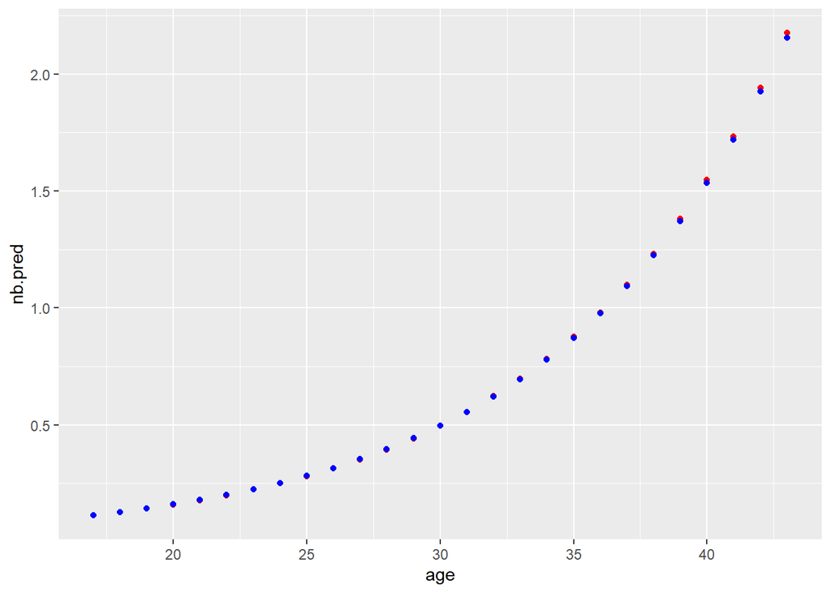

```r
birthdata$nb.pred<-birth.nb$fitted.values
birthdata$poi.pred<-birth.poi$fitted.values
gg<- ggplot(data=birthdata, aes(x=age, y=nb.pred))
gg + geom_point(color="red") + geom_point( aes(x=age, y=poi.pred), color="blue")
```

## 6)

```r
lrtest(birth.poi, birth.nb)
```

```
## Likelihood ratio test
##
## Model 1: children ~ age
## Model 2: children ~ age
##   #Df  LogLik Df  Chisq Pr(>Chisq)
## 1   2 -142.99
## 2   3 -139.79  1 6.3973    0.01143 *
## ---
## Signif. codes:  0 '***' 0.001 '**' 0.01 '*' 0.05 '.' 0.1 ' ' 1
```

- 포아송회귀모형(-142.99)보다 음이항회귀모형식(-139.79)이 크다. 그러므로 음이항회귀모형식이 더 낫다는 것을 볼 수 있다.

# 3.

```r
diabetes <-  as.data.frame(read_excel("C:/Users/nabib/Documents/GitHub/Statics/1021/diabetes.xlsx"))
diabetes
```

```
##    gender   age deaths    popn agemidpt
## 1    Male   <25      3 1141100       20
## 2    Male 25-34      0  485571       30
## 3    Male 35-44     12  504312       40
## 4    Male 45-54     25  447315       50
## 5    Male 55-64     61  330902       60
## 6    Male 65-74    130  226403       70
## 7    Male 75-84    192  130527       80
## 8    Male   85+    102   29785       90
## 9  Female   <25      2 1086408       20
## 10 Female 25-34      1  489948       30
## 11 Female 35-44      3  504030       40
## 12 Female 45-54     11  445763       50
## 13 Female 55-64     30  323669       60
## 14 Female 65-74     63  241488       70
## 15 Female 75-84    174  179686       80
## 16 Female   85+    159   67203       90
```

## 1)

```r
str(diabetes)
```

```
## 'data.frame':    16 obs. of  5 variables:
##  $ gender  : chr  "Male" "Male" "Male" "Male" ...
##  $ age     : chr  "<25" "25-34" "35-44" "45-54" ...
##  $ deaths  : num  3 0 12 25 61 130 192 102 2 1 ...
##  $ popn    : num  1141100 485571 504312 447315 330902 ...
##  $ agemidpt: num  20 30 40 50 60 70 80 90 20 30 ...
```

```r
diabetes <- diabetes %>% mutate(gender=factor(gender), age=factor(age))
str(diabetes)
```

```
## 'data.frame':    16 obs. of  5 variables:
##  $ gender  : Factor w/ 2 levels "Female","Male": 2 2 2 2 2 2 2 2 1 1 ...
##  $ age     : Factor w/ 8 levels "<25","25-34",..: 1 2 3 4 5 6 7 8 1 2 ...
##  $ deaths  : num  3 0 12 25 61 130 192 102 2 1 ...
##  $ popn    : num  1141100 485571 504312 447315 330902 ...
##  $ agemidpt: num  20 30 40 50 60 70 80 90 20 30 ...
```

```r
dia.poi1 <- glm(deaths ~ gender + agemidpt + popn, family = poisson, data=diabetes)
summary(dia.poi1)
```

```
##
## Call:
## glm(formula = deaths ~ gender + agemidpt + popn, family = poisson,
##     data = diabetes)
##
## Deviance Residuals:
##     Min       1Q   Median       3Q      Max
## -8.7556  -2.6043  -1.5347   0.6015   5.6840
##
## Coefficients:
##               Estimate Std. Error z value Pr(>|z|)
## (Intercept) -6.517e-01  6.375e-01  -1.022  0.30665
## genderMale   2.030e-01  6.683e-02   3.037  0.00239 **
## agemidpt     6.441e-02  6.773e-03   9.510  < 2e-16 ***
## popn         1.166e-06  6.153e-07   1.895  0.05804 .
## ---
## Signif. codes:  0 '***' 0.001 '**' 0.01 '*' 0.05 '.' 0.1 ' ' 1
##
## (Dispersion parameter for poisson family taken to be 1)
##
##     Null deviance: 1209.40  on 15  degrees of freedom
## Residual deviance:  226.82  on 12  degrees of freedom
## AIC: 310.43
##
## Number of Fisher Scoring iterations: 5
```

- 성별: 범주, 연령: 중앙값, 1차항

```r
dia.poi2 <- glm(deaths ~ gender + agemidpt + popn + agemidpt, family = poisson, data=diabetes)
summary(dia.poi2)
```

```
##
## Call:
## glm(formula = deaths ~ gender + agemidpt + popn + agemidpt, family = poisson,
##     data = diabetes)
##
## Deviance Residuals:
##     Min       1Q   Median       3Q      Max
## -8.7556  -2.6043  -1.5347   0.6015   5.6840
##
## Coefficients:
##               Estimate Std. Error z value Pr(>|z|)
## (Intercept) -6.517e-01  6.375e-01  -1.022  0.30665
## genderMale   2.030e-01  6.683e-02   3.037  0.00239 **
## agemidpt     6.441e-02  6.773e-03   9.510  < 2e-16 ***
## popn         1.166e-06  6.153e-07   1.895  0.05804 .
## ---
## Signif. codes:  0 '***' 0.001 '**' 0.01 '*' 0.05 '.' 0.1 ' ' 1
##
## (Dispersion parameter for poisson family taken to be 1)
##
##     Null deviance: 1209.40  on 15  degrees of freedom
## Residual deviance:  226.82  on 12  degrees of freedom
## AIC: 310.43
##
## Number of Fisher Scoring iterations: 5
```

```r
dia.poi3 <- glm(deaths ~ gender + age, family = poisson, data=diabetes)
summary(dia.poi3)
```

```
##
## Call:
## glm(formula = deaths ~ gender + age, family = poisson, data = diabetes)
##
## Deviance Residuals:
##     Min       1Q   Median       3Q      Max
## -3.5008  -1.4928  -0.0114   1.2064   3.4428
##
## Coefficients:
##             Estimate Std. Error z value Pr(>|z|)
## (Intercept)  0.82778    0.44858   1.845  0.06499 .
## genderMale   0.16983    0.06451   2.632  0.00848 **
## age25-34    -1.60944    1.09544  -1.469  0.14177
## age35-44     1.09861    0.51640   2.127  0.03338 *
## age45-54     1.97408    0.47726   4.136 3.53e-05 ***
## age55-64     2.90142    0.45934   6.317 2.67e-10 ***
## age65-74     3.65325    0.45297   8.065 7.32e-16 ***
## age75-84     4.29320    0.45026   9.535  < 2e-16 ***
## age85+       3.95508    0.45148   8.760  < 2e-16 ***
## ---
## Signif. codes:  0 '***' 0.001 '**' 0.01 '*' 0.05 '.' 0.1 ' ' 1
##
## (Dispersion parameter for poisson family taken to be 1)
##
##     Null deviance: 1209.401  on 15  degrees of freedom
## Residual deviance:   53.966  on  7  degrees of freedom
## AIC: 147.57
##
## Number of Fisher Scoring iterations: 5
```

## 2)

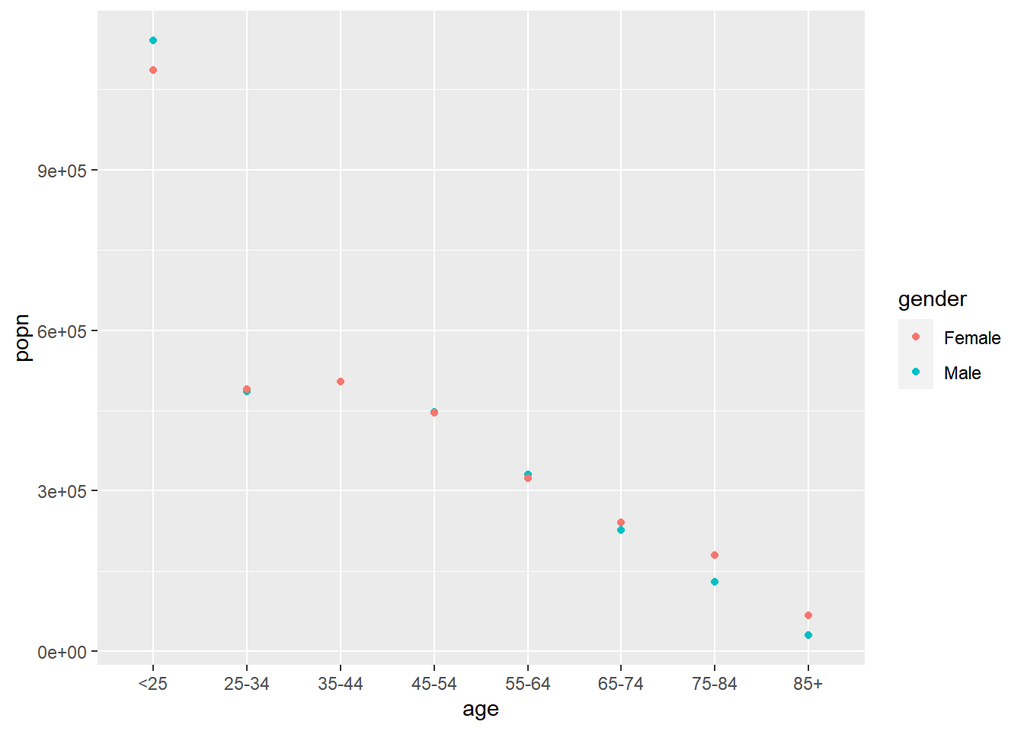

```r
ggplot(data=diabetes, aes(x=age, y=popn, col=gender)) + geom_point()
```

## 3)

```r
predict(dia.poi3, newdata = data.frame(gender="Male", age="55-64", popn=500000))
```

```
##        1
## 3.899026
```

```r
predict(dia.poi3, newdata = data.frame(gender="Female", age="75-84", popn=70000))
```

```
##        1
## 5.120971
```

- 남성 예측값: 3.899026, 여성 예측값: 5.120971

```r
confint(dia.poi3)
```

```
##                  2.5 %    97.5 %
## (Intercept) -0.1998952 1.5963688
## genderMale   0.0435665 0.2965428
## age25-34    -4.5622144 0.2151854
## age35-44     0.1504401 2.2218727
## age45-54     1.1308741 3.0425063
## age55-64     2.1050830 3.9444223
## age65-74     2.8733567 4.6871858
## age75-84     3.5202702 5.3232561
## age85+       3.1790262 4.9868850
```

- 신뢰구간

## 4)

```r
diabetes$deathrate <- prop.table(diabetes$deaths)
```

```r
dia.poi4 <- glm(deathrate ~ gender + age, family = poisson, data=diabetes)
summary(dia.poi4)
```

```
##
## Call:
## glm(formula = deathrate ~ gender + age, family = poisson, data = diabetes)
##
## Deviance Residuals:
##       Min         1Q     Median         3Q        Max
## -0.112521  -0.047982  -0.000365   0.038777   0.110657
##
## Coefficients:
##             Estimate Std. Error z value Pr(>|z|)
## (Intercept)  -6.0475    13.9565  -0.433    0.665
## genderMale    0.1698     2.0072   0.085    0.933
## age25-34     -1.6094    34.0806  -0.047    0.962
## age35-44      1.0986    16.0665   0.068    0.945
## age45-54      1.9741    14.8489   0.133    0.894
## age55-64      2.9014    14.2912   0.203    0.839
## age65-74      3.6533    14.0931   0.259    0.795
## age75-84      4.2932    14.0087   0.306    0.759
## age85+        3.9551    14.0467   0.282    0.778
##
## (Dispersion parameter for poisson family taken to be 1)
##
##     Null deviance: 1.24938  on 15  degrees of freedom
## Residual deviance: 0.05575  on  7  degrees of freedom
## AIC: Inf
##
## Number of Fisher Scoring iterations: 9
```

- AIC값이 굉장히 커졌다.

```r
predict(dia.poi4, newdata = data.frame(gender="Male", age="55-64", popn=500000))
```

```
##         1
## -2.976206
```

```r
predict(dia.poi4, newdata = data.frame(gender="Female", age="75-84", popn=70000))
```

```
##         1
## -1.754261
```

- 남성 예측값: -2.976206, 여성 예측값: -1.754261